# Cross-ancestry LD differentials and association mapping

Consider a causal SNP $g$ has an influence on $x$ of $\beta_x$, and standard error

$$\begin{aligned}
se_{\beta_x} & = \sqrt{\frac{\sigma^2}{2np(1-p)}} \\
& = \sqrt{\frac{Var(x) - 2p(1-p)\beta_x^2}{2p(1-p)n}} \\
& = \sqrt{\frac{Var(x)}{2p(1-p)n} - \frac{\beta^2}{n}}
\end{aligned}$$

where $\sigma^2$ is the residual error variance. The effect estimate at a neighbouring SNP will be $\beta_{o_k} = r^2(o_k, x)\beta_x$ and so $\sigma^2_{o_k} = var(x) - 2p(1-p)\beta_{o_k}^2r^2(x,o_k)$.

For a causal variant, find the probability of neighbouring SNPs being the causal variant. Then for each of the neighbouring SNPs being the causal variant, ask what probability that they would replicate in a different population. OK!

| chr | snp | pos | alt | ref | af | region |
| --- | --- | --- | --- | --- | --- | --- |
| 2 | rs11683443 | 14335308 | G | A | 0.65210 | 2_14335308_16329735 |
| 2 | rs113991338 | 14336045 | A | C | 0.06362 | 2_14335308_16329735 |
| 2 | rs7604240 | 14336149 | A | G | 0.78230 | 2_14335308_16329735 |
| 2 | rs73916637 | 14337254 | A | G | 0.05169 | 2_14335308_16329735 |
| 2 | rs79612322 | 14338623 | C | T | 0.05169 | 2_14335308_16329735 |
| 2 | rs10188720 | 14338648 | A | G | 0.59940 | 2_14335308_16329735 |

```r
glimpse(ldobjs)
```

```
List of 5
 $ EUR:List of 3
  ..$ ld  : num [1:4203, 1:4203] 1 0.726 0.89 0.61 0.847 ...
  .. ..- attr(*, "dimnames")=List of 2
  ..$ map : tibble [4,203 × 6] (S3: tbl_df/tbl/data.frame)
  .. ..- attr(*, ".internal.selfref")=<externalptr>
  ..$ nref: num 503
 $ EAS:List of 3
  ..$ ld  : num [1:4203, 1:4203] 1 0.572 0.64 0.606 0.941 ...
  .. ..- attr(*, "dimnames")=List of 2
  ..$ map : tibble [4,203 × 6] (S3: tbl_df/tbl/data.frame)
  .. ..- attr(*, ".internal.selfref")=<externalptr>
  ..$ nref: num 504
 $ SAS:List of 3
  ..$ ld  : num [1:4203, 1:4203] 1 0.72 0.768 0.532 0.765 ...
  .. ..- attr(*, "dimnames")=List of 2
  ..$ map : tibble [4,203 × 6] (S3: tbl_df/tbl/data.frame)
  .. ..- attr(*, ".internal.selfref")=<externalptr>
  ..$ nref: num 489
 $ AFR:List of 3
  ..$ ld  : num [1:4203, 1:4203] 1 0.192 0.692 0.126 -0.12 ...
  .. ..- attr(*, "dimnames")=List of 2
  ..$ map : tibble [4,203 × 6] (S3: tbl_df/tbl/data.frame)
  .. ..- attr(*, ".internal.selfref")=<externalptr>
  ..$ nref: num 661
 $ AMR:List of 3
  ..$ ld  : num [1:4203, 1:4203] 1 0.72 0.756 0.61 0.835 ...
  .. ..- attr(*, "dimnames")=List of 2
  ..$ map : tibble [4,203 × 6] (S3: tbl_df/tbl/data.frame)
  .. ..- attr(*, ".internal.selfref")=<externalptr>
  ..$ nref: num 347
```

```r
tempmap <- ldobjs[["EUR"]]$map
causalsnp <- sample(1:nrow(tempmap), 1)

ldscore <- colSums(ldobjs$EUR$ld)
#causalsnp <- which.max(ldscore)
beta <- 0.1
tempmap$causal <- 1:nrow(tempmap) == causalsnp
which(tempmap$causal)
```

```
[1] 598
```

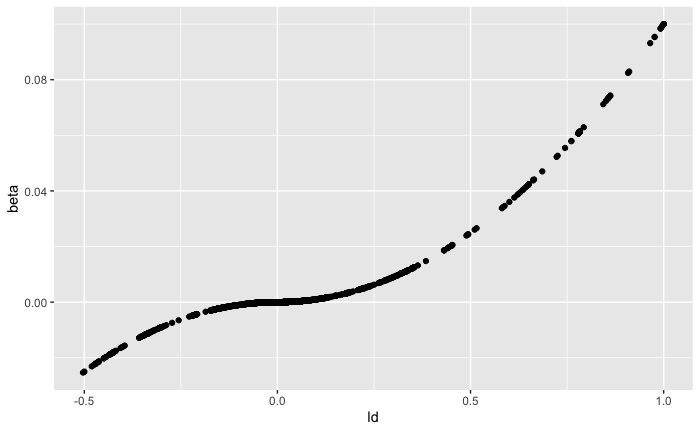

```r
tempmap$ld <- ldobjs$EUR$ld[causalsnp, ]
tempmap$beta <- beta * sign(tempmap$ld) * tempmap$ld^2
tempmap$se <- expected_se(tempmap$beta, tempmap$af, 100000, 1)
ggplot(tempmap, aes(ld, beta)) +
  geom_point()
```

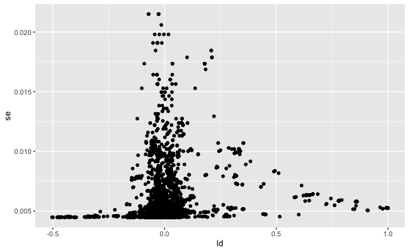

```r
ggplot(tempmap, aes(ld, se)) +
  geom_point()
```

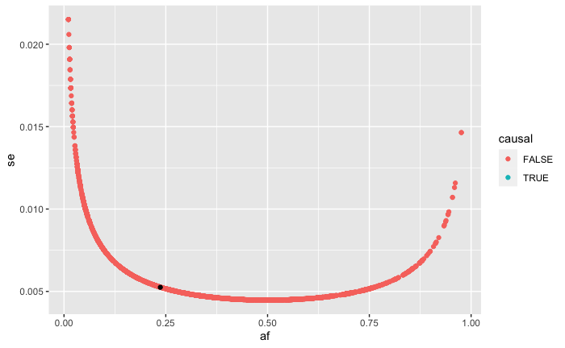

```r
ggplot(tempmap, aes(af, se)) +
  geom_point(aes(colour=causal)) +
  geom_point(data=subset(tempmap, causal))
```

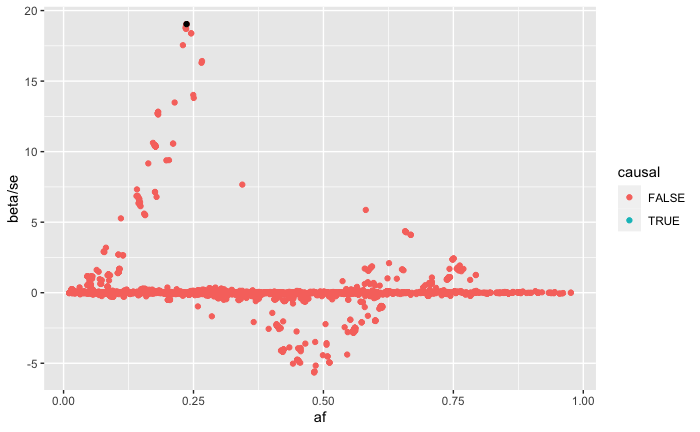

```r
ggplot(tempmap, aes(af, beta/se)) +
  geom_point(aes(colour=causal)) +
  geom_point(data=subset(tempmap, causal))
```

Notice that allele frequency has a big impact on standard error

For each SNP in the region we now have its expected effect and expected standard error. Next question is what is the probability for each SNP being the top hit? Simple approximation is to ask probability of each SNP being larger than the top hit, and dividing by the sum of all probabilities

[figure not shown]

Now we have a probability distribution for a SNP being selected as the tophit in the discovery. Next we can ask: what is the expected rsq for the discovery hit with the causal variant in a new population?

```r
#tempmap <- subset(tempmap, prob_tophit2 > 0.001)
sapply(ldobjs, function(x){
  x <- subset_ldobj(x, tempmap$snp)$ld[tempmap$causal,]
  sum(x * tempmap$prob_tophit2) / sum(tempmap$prob_tophit2)
})
```

```
      EUR       EAS       SAS       AFR       AMR
0.9945787 0.9875621 0.9727533 0.8056082 0.9903871
```

Wrap that up. Choose SNP effects that will give an expected discovery pval of 5e-8

| snp | pop | r2 |
| --- | --- | --- |
| rs11683443 | EUR | 0.1911409 |
| rs11683443 | EAS | 0.1494998 |
| rs11683443 | SAS | 0.1745965 |
| rs11683443 | AFR | 0.0951074 |
| rs11683443 | AMR | 0.1145608 |

Do it for lots of SNPs

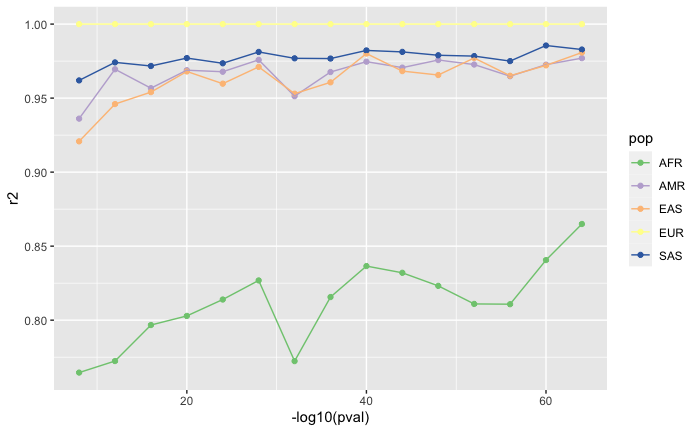

```r
res %>% group_by(snp, pval) %>%
  mutate(r2=r2/r2[1]) %>%
  group_by(pop, pval) %>%
  summarise(r2=mean(r2)) %>%
  ggplot(., aes(x=-log10(pval), y=r2)) +
    geom_point(aes(colour=pop)) +
    geom_line(aes(colour=pop)) +
    scale_color_brewer(type="qual")
```

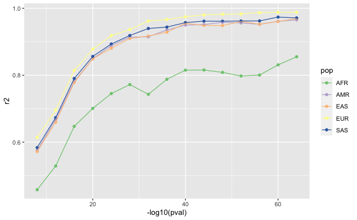

```r
res %>%
  group_by(pop, pval) %>%
  summarise(r2=mean(r2)) %>%
  ggplot(., aes(x=-log10(pval), y=r2)) +
    geom_point(aes(colour=pop)) +
    geom_line(aes(colour=pop)) +
    scale_color_brewer(type="qual")
```

What about if there are multiple causal variants?

```r
tophit_cross_ancestry_ld_loss_multiple <- function(tempmap, ncausal, pval, nEUR, ldobjs)
{
  causalsnp <- sample(1:nrow(tempmap), ncausal, replace=FALSE)
  tempmap$causal <- 1:nrow(tempmap) %in% causalsnp
  tempmap$beta <- 0
  tempmap$beta[tempmap$causal] <- b_from_pafn(pval, tempmap$af[tempmap$causal], nEUR) * sample(c(-1, 1), ncausal, replace=TRUE)
  xvar <- sqrt(2 * tempmap[["af"]] * (1-tempmap[["af"]]))
    tempmap$beta <- (diag(1/xvar) %*% ldobjs$EUR$ld %*% diag(xvar) %*% tempmap$beta) %>% drop()
  tempmap$se <- expected_se(tempmap$beta, tempmap$af, nEUR, 1)
  # The probability that each SNP has a larger assoc than the causal variant
  tophit <- which.max(tempmap$beta)[1]
  tempmap$prob_tophit <- sapply(1:nrow(tempmap), function(i) prob_y_gt_x(tempmap$beta[i], tempmap$se[i], tempmap$beta[tophit], tempmap$se[tophit]))
  # The scaled probability of being
  tempmap$prob_tophit2 <- tempmap$prob_tophit / sum(tempmap$prob_tophit)
  r2 <- sapply(ldobjs, function(x){
    x <- subset_ldobj(x, tempmap$snp)$ld[tophit,]
    sum(x * tempmap$prob_tophit2) / sum(tempmap$prob_tophit2)
  })
  return(list(tempmap, tibble(ncausal=ncausal, pop=names(r2), r2=r2)))
}
resm <- lapply(2:10, function(nc)
  {
    lapply(1:100, function(sim) tophit_cross_ancestry_ld_loss_multiple(tempmap, nc, 5e-8, 100000, ldobjs)[[2]] %>% mutate(sim=sim)) %>% bind_rows()
  }) %>% bind_rows()
```

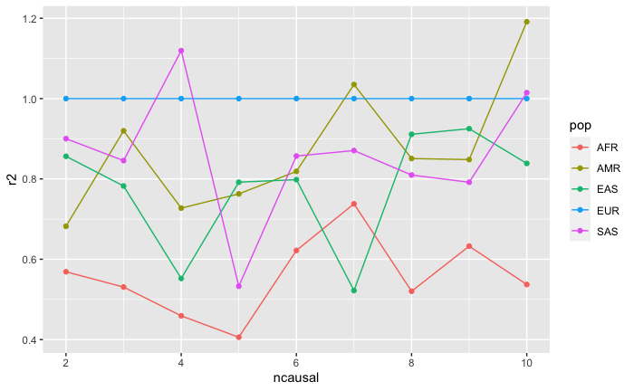

```r
group_by(resm, ncausal, sim) %>%
  mutate(r2=r2/r2[1]) %>%
  group_by(ncausal, pop) %>%
  summarise(r2=mean(r2)) %>%
  ggplot(., aes(x=ncausal, y=r2)) +
  geom_point(aes(colour=pop)) +
  geom_line(aes(colour=pop))
```

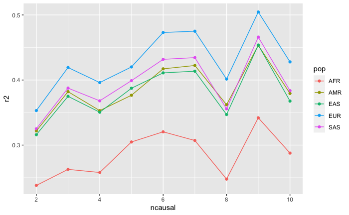

```r
resm %>%
  group_by(ncausal, pop) %>%
  summarise(r2=mean(r2)) %>%
  ggplot(., aes(x=ncausal, y=r2)) +
  geom_point(aes(colour=pop)) +
  geom_line(aes(colour=pop))
```

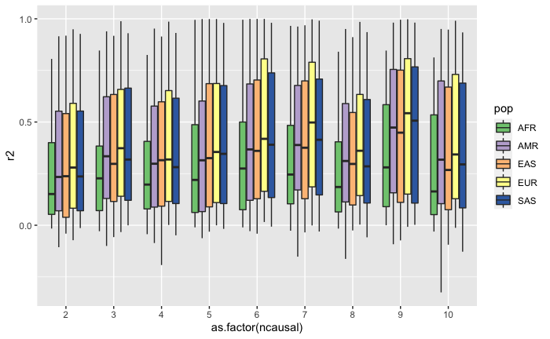

```r
resm %>%
  ggplot(., aes(as.factor(ncausal), r2)) +
  geom_boxplot(aes(fill=pop)) + scale_fill_brewer(type="qual")
```

## Summary

- If you use European exposure on non-European outcome there will be a problem because the expected bgy = bgx * bxy. If bxy is the same across populations and bgx and bgy are taken from different populations then there will be bias.
- This bias isn’t massively affected by the complexity of the region e.g. 1 causal variant vs 10 causal variants gives the same issue